# ML para tomada de decisões

Andre

2/3/2020

# MACHINE LEARNING PARA TOMADA DE DECISÕES: ROTEIRO e CÓDIGOS

Este roteiro, anexo à Dissertacao, busca demonstrar a construcao de uma ferramenta utilizada para prever o crescimento da margem de contribuicao e volume de investimentos de clientes, de acordo com suas características e com o atendimento a eles prestado: presencial ou digital.

Com isso sera possível identificar qual o melhor modelo de relacionamento para determinado perfil de cliente para que se observe elevacao nesses indicadores.

Este anexo ao trabalho Machine Learning para Tomadas de decisao em processos de transformacao digital foi construído em linguagem R, com a utilizacao do software RStudio, com a utilizacao de diversos pacotes como: Tidyverse, Dplyr, GGplot2, Caret, RMarkdown dentre outros.

## 1. Instalacao de pacotes

## 2. Importacao e limpeza dos dados

## 3. Transformacões nos dados

-Verificar estrutura das variaveis e escolher o tipo que melhor represente os dados no modelo

```
## 'data.frame':    29191 obs. of  17 variables:
##  $ UF                    : chr  "SP" "TO" "RS" "SP" ...
##  $ CIDADE                : chr  "SAO PAULO" "PALMAS" "SERTAO SANTANA" "SAO BERNARDO DO CAMPO" ...
##  $ SEXO                  : chr  "M" "M" "M" "M" ...
##  $ ESCOLARIDADE          : chr  "SUPERIOR EM ANDAMENTO" "SUPERIOR COMPLETO" "ENSINO FUNDAMENTAL" "ENSINO FUNDAMENTAL" ...
##  $ CLIENTE_DESDE         : chr  "24/03/2008" "02/03/2010" "12/12/1989" "09/09/1996" ...
##  $ PREFIXO_RELACIONAMENTO: int  8249 9206 4401 9203 4327 9976 645 9151 2636 4448 ...
##  $ NOME_AGENCIA          : chr  "ESCR.EXC.SOROCABA" "ESCR.EXC.PALMAS" "SERTAO SANTANA" "ESCR.EXC.PAULISTANO" ...
##  $ ENCARTEIRAMENTO       : int  56 56 17 56 56 56 17 56 56 56 ...
##  $ SEGMENTACAO           : int  2602 2112 2602 2702 2602 2602 2602 2602 2112 2602 ...
##  $ RENDA                 : num  7270 6916 976 2293 5399 ...
##  $ DT_NASCIMENTO         : chr  "25/04/1990" "01/02/1986" "28/05/1943" "01/04/1962" ...
##  $ TARIFA_062019         : num  460.4 178.8 1028.6 29.3 90.2 ...
##  $ TARIFA_062016         : chr  "472,36" "202,5" " 1.154,70 " "504,13" ...
##  $ VOLUME_062019         : num  477570 18060 852464 805638 179323 ...
##  $ VOLUME_062016         : num  471382 37805 601385 337739 376183 ...
##  $ MARGEM_062019         : num  940 295 1053 11654 -119 ...
##  $ MARGEM_062016         : num  759 251 1107 11297 682 ...
```

```
##       UF               CIDADE              SEXO           ESCOLARIDADE
##  Length:29191       Length:29191       Length:29191       Length:29191
##  Class :character   Class :character   Class :character   Class :character
##  Mode  :character   Mode  :character   Mode  :character   Mode  :character
##
##
##
##  CLIENTE_DESDE      PREFIXO_RELACIONAMENTO NOME_AGENCIA       ENCARTEIRAMENTO
##  Length:29191       Min.   :  12           Length:29191       Min.   :17
##  Class :character   1st Qu.:3850           Class :character   1st Qu.:17
##  Mode  :character   Median :7047           Mode  :character   Median :56
##                     Mean   :6161                              Mean   :43
##                     3rd Qu.:9138                              3rd Qu.:56
##                     Max.   :9976                              Max.   :68
##   SEGMENTACAO       RENDA        DT_NASCIMENTO      TARIFA_062019
##  Min.   :2012   Min.   :    71   Length:29191       Min.   :-12712
##  1st Qu.:2602   1st Qu.:  4093   Class :character   1st Qu.:   131
##  Median :2602   Median :  5493   Mode  :character   Median :   406
##  Mean   :2489   Mean   :  6925                      Mean   :   888
##  3rd Qu.:2602   3rd Qu.:  7969                      3rd Qu.:   918
##  Max.   :9998   Max.   :838806                      Max.   :378336
##  TARIFA_062016      VOLUME_062019        VOLUME_062016       MARGEM_062019
##  Length:29191       Min.   :         0   Min.   :        0   Min.   :-3715549
##  Class :character   1st Qu.:     29234   1st Qu.:    18702   1st Qu.:     142
##  Mode  :character   Median :    183038   Median :   141407   Median :     907
##                     Mean   :    916789   Mean   :   683188   Mean   :    6572
##                     3rd Qu.:    699780   3rd Qu.:   561126   3rd Qu.:    4473
##                     Max.   :1117350760   Max.   :461510914   Max.   :14421064
##  MARGEM_062016
##  Min.   :-557606
##  1st Qu.:    316
##  Median :   1061
##  Mean   :   5044
##  3rd Qu.:   4103
##  Max.   :1246902
```

Eliminacao do separador de milhar da variavel TARIFA_062016 e conversao para variavel numérica.

```r
base$TARIFA_062016[base$TARIFA_062016 == " -   "] <- NA
base$TARIFA_062016 <- gsub("\\.", "", base$TARIFA_062016)
base$TARIFA_062016 <- as.numeric(gsub(",", ".", base$TARIFA_062016))
```

Transformacao de variaveis para datas:

```r
base$CLIENTE_DESDE<-as.Date(base$CLIENTE_DESDE, "%d/%m/%Y")
base$DT_NASCIMENTO<-as.Date(base$DT_NASCIMENTO, "%d/%m/%Y")
```

Transformacao das variaveis que foram classificadas como números ou texto, quando na verdade sao fatores.

```r
base$UF <- as.factor(base$UF)
base$CIDADE <- as.factor(base$CIDADE)
base$SEXO <- factor(base$SEXO, labels = c("M", "F"))
base$PREFIXO_RELACIONAMENTO <- as.factor(base$PREFIXO_RELACIONAMENTO)
base$ENCARTEIRAMENTO <- as.factor(base$ENCARTEIRAMENTO)
```

A variavel escolaridade, possui níveis ordenados, que devem ser redefinidos por estarem incorretos:

```r
base$ESCOLARIDADE <- factor(base$ESCOLARIDADE,
                            levels=c("ANALFABETO", "ENSINO FUNDAMENTAL",
                                     "ENSINO MEDIO", "SUPERIOR EM ANDAMENTO",
                                     "SUPERIOR COMPLETO", "POS GRADUADO",
                                     "MESTRADO", "DOUTORADO"),
                            ordered = TRUE)
```

Remocao de casos com valores omitidos e observações com VI em 06/2016 e 06/2019 iguais a zero.

```r
base <- na.omit(base)
summary(base)
```

```
##        UF                   CIDADE      SEXO                     ESCOLARIDADE
##  SP     : 6984   SAO PAULO     : 2545   M:13806   SUPERIOR COMPLETO    :11702
##  MG     : 2514   RIO DE JANEIRO: 1142   F:14014   ENSINO MEDIO         : 9915
##  RJ     : 1936   BRASILIA      :  972             ENSINO FUNDAMENTAL   : 3274
##  BA     : 1691   SALVADOR      :  755             SUPERIOR EM ANDAMENTO: 1778
##  SC     : 1604   BELO HORIZONTE:  698             POS GRADUADO         :  705
##  PR     : 1477   CURITIBA      :  501             MESTRADO             :  221
##  (Other):11614   (Other)       :21207             (Other)              :  225
##  CLIENTE_DESDE        PREFIXO_RELACIONAMENTO NOME_AGENCIA       ENCARTEIRAMENTO
##  Min.   :1943-06-10   4925   : 1189          Length:27820       17: 8438
##  1st Qu.:1998-02-18   9153   :  229          Class :character   56:19077
##  Median :2003-06-30   8245   :  221          Mode  :character   64:  210
##  Mean   :2002-10-18   9198   :  215                             68:   95
##  3rd Qu.:2009-06-30   7648   :  210
##  Max.   :2019-05-14   5932   :  208
##                       (Other):25548
##   SEGMENTACAO       RENDA        DT_NASCIMENTO        TARIFA_062019
##  Min.   :2012   Min.   :    71   Min.   :1930-01-02   Min.   :-12712
##  1st Qu.:2112   1st Qu.:  4105   1st Qu.:1957-12-26   1st Qu.:   159
##  Median :2602   Median :  5529   Median :1970-05-20   Median :   437
##  Mean   :2488   Mean   :  6969   Mean   :1969-06-19   Mean   :   927
##  3rd Qu.:2602   3rd Qu.:  8000   3rd Qu.:1981-08-13   3rd Qu.:   956
##  Max.   :9998   Max.   :838806   Max.   :2029-12-20   Max.   :378336
##
##  TARIFA_062016    VOLUME_062019        VOLUME_062016       MARGEM_062019
##  Min.   : -4699   Min.   :         0   Min.   :        0   Min.   :-3715549
##  1st Qu.:   163   1st Qu.:     34825   1st Qu.:    23987   1st Qu.:     178
##  Median :   395   Median :    199332   Median :   158036   Median :    1007
##  Mean   :   793   Mean   :    953786   Mean   :   710884   Mean   :    6867
##  3rd Qu.:   805   3rd Qu.:    737042   3rd Qu.:   591406   3rd Qu.:    4845
##  Max.   :478608   Max.   :1117350760   Max.   :461510914   Max.   :14421064
##
##  MARGEM_062016
##  Min.   :-557606
##  1st Qu.:    376
##  Median :   1172
##  Mean   :   5275
##  3rd Qu.:   4395
##  Max.   :1246902
##
```

```r
base <- subset(base, VOLUME_062016>0&VOLUME_062019>0)

str(base)
```

```
## 'data.frame':    27151 obs. of  17 variables:
##  $ UF                    : Factor w/ 27 levels "AC","AL","AM",..: 26 27 23 26 26 26 18 19 7 13 ...
##  $ CIDADE                : Factor w/ 3183 levels "ABADIA DE GOIAS",..: 2766 2037 2865 2623 2766 2766 877 3173 429 3114 ...
##  $ SEXO                  : Factor w/ 2 levels "M","F": 2 2 2 2 1 1 2 1 1 1 ...
##  $ ESCOLARIDADE          : Ord.factor w/ 8 levels "ANALFABETO"<"ENSINO FUNDAMENTAL"<..: 4 5 2 2 5 4 4 5 5 5 ...
##  $ CLIENTE_DESDE         : Date, format: "2008-03-24" "2010-03-02" ...
##  $ PREFIXO_RELACIONAMENTO: Factor w/ 2647 levels "12","14","15",..: 2527 2641 2021 2638 1998 2647 436 2598 1461 2039 ...
##  $ NOME_AGENCIA          : chr  "ESCR.EXC.SOROCABA" "ESCR.EXC.PALMAS" "SERTAO SANTANA" "ESCR.EXC.PAULISTANO" ...
##  $ ENCARTEIRAMENTO       : Factor w/ 4 levels "17","56","64",..: 2 2 1 2 2 2 1 2 2 2 ...
##  $ SEGMENTACAO           : int  2602 2112 2602 2702 2602 2602 2602 2602 2112 2602 ...
##  $ RENDA                 : num  7270 6916 976 2293 5399 ...
##  $ DT_NASCIMENTO         : Date, format: "1990-04-25" "1986-02-01" ...
##  $ TARIFA_062019         : num  460.4 178.8 1028.6 29.3 90.2 ...
##  $ TARIFA_062016         : num  472 202 1155 504 149 ...
##  $ VOLUME_062019         : num  477570 18060 852464 805638 179323 ...
##  $ VOLUME_062016         : num  471382 37805 601385 337739 376183 ...
##  $ MARGEM_062019         : num  940 295 1053 11654 -119 ...
##  $ MARGEM_062016         : num  759 251 1107 11297 682 ...
```

-Criacao de Variaveis necessarias para a análise exploratória: Variaveis calculadas a partir da variacao entre os indicadores entre os períodos.

Criacao da variavel relacionamento a partir da variavel Encarteiramento que determina o tipo de atendimento prestado.

```r
base$RELACIONAMENTO <- ifelse(base$ENCARTEIRAMENTO == 17, "TRADICIONAL", "DIGITAL")
base$RELACIONAMENTO <- factor(base$RELACIONAMENTO, labels = c("TRADICIONAL", "DIGITAL"))
```

Criação da variável Regiao.

```r
Estados <- read.csv(file="Estados.csv", sep= ";", encoding = "UTF-8")
names(Estados)[1] <- "UF"
colnames(Estados) <- c("UF","REGIAO")
Estados$UF <- as.factor(Estados$UF)
Estados$REGIAO <- as.factor(Estados$REGIAO)

base <- left_join(base, Estados, by="UF")
```

Criacao, a partir das datas, de nascimento e cliente desde, de novas variáveis para representar a década, para auxiliar na análise exploratória, e para representar apenas a idade e o tempo de relacionamento, possibilitando a realização de um correlograma das variáveis no corrgram, e a inclusão no modelo em detrimento da data, o que pode gerar melhor performance.

```r
br <- seq(1920,2010, by=10)
base$ANO_NASCIMENTO <- lubridate::year(base$DT_NASCIMENTO)
base$IDADE <- 2020 - base$ANO_NASCIMENTO
base$DEC_NASCIMENTO <- cut(base$ANO_NASCIMENTO, breaks=br)
levels(base$DEC_NASCIMENTO) <- br

br2 <- seq(1950,2020, by=10)
base$ANO_DESDE <- year(base$CLIENTE_DESDE)
base$TEMPO_REL <- 2020 - base$ANO_DESDE
base$DEC_DESDE <- cut(base$ANO_DESDE, breaks=br2)
base$DEC_DESDE <- as.factor(as.numeric(base$DEC_DESDE))
levels(base$DEC_DESDE) <- br2
```

Removendo variáveis que não seráo utilizadas do Data frame

```r
base <- base[,-c(2,6,7,8,9,12,16)]
```

```r
base <- base %>% mutate(id = row_number())

base <- base[,c(21,1:20)]
```

Removendo clientes nascidos a partir de 2002, uma vez que sao tutelados, sendo o atendimento prestados a representantes.

```r
base <- subset(base, DT_NASCIMENTO < "2002-01-01")
head(sort(base$DT_NASCIMENTO, decreasing = TRUE))
```

```
## [1] "2001-10-17" "2001-02-09" "2000-09-20" "2000-08-07" "2000-06-05"
## [6] "2000-05-03"
```

Como pode ser verificado, as variaveis foram convertidas para o formato devido.

```r
str(base)
```

```
## 'data.frame':    27091 obs. of  21 variables:
##  $ id             : int  1 2 3 4 5 6 7 8 9 10 ...
##  $ UF             : Factor w/ 27 levels "AC","AL","AM",..: 26 27 23 26 26 26 18 19 7 13 ...
##  $ SEXO           : Factor w/ 2 levels "M","F": 2 2 2 2 1 1 2 1 1 1 ...
##  $ ESCOLARIDADE   : Ord.factor w/ 8 levels "ANALFABETO"<"ENSINO FUNDAMENTAL"<..: 4 5 2 2 5 4 4 5 5 5 ...
##  $ CLIENTE_DESDE  : Date, format: "2008-03-24" "2010-03-02" ...
##  $ RENDA          : num  7270 6916 976 2293 5399 ...
##  $ DT_NASCIMENTO  : Date, format: "1990-04-25" "1986-02-01" ...
##  $ TARIFA_062016  : num  472 202 1155 504 149 ...
##  $ VOLUME_062019  : num  477570 18060 852464 805638 179323 ...
##  $ VOLUME_062016  : num  471382 37805 601385 337739 376183 ...
##  $ MARGEM_062016  : num  759 251 1107 11297 682 ...
##  $ DELTA_V        : num  6188 -19745 251079 467899 -196860 ...
##  $ PercDeltaVolume: num  1.31 -52.23 41.75 138.54 -52.33 ...
##  $ RELACIONAMENTO : Factor w/ 2 levels "TRADICIONAL",..: 1 1 2 1 1 1 2 1 1 1 ...
##  $ REGIAO         : Factor w/ 5 levels "Centroeste","Nordeste",..: 4 3 5 4 4 4 5 4 1 1 ...
##  $ ANO_NASCIMENTO : num  1990 1986 1943 1962 1956 ...
##  $ IDADE          : num  30 34 77 58 64 29 27 42 56 66 ...
##  $ DEC_NASCIMENTO : Factor w/ 10 levels "1920","1930",..: 7 7 3 5 4 8 8 6 5 4 ...
##  $ ANO_DESDE      : num  2008 2010 1989 1996 2009 ...
##  $ TEMPO_REL      : num  12 10 31 24 11 8 5 5 26 22 ...
##  $ DEC_DESDE      : Factor w/ 8 levels "1950","1960",..: 6 6 4 5 6 7 7 7 5 5 ...
```

```r
summary(base)
```

```
##        id              UF        SEXO                     ESCOLARIDADE
##  Min.   :    1   SP     : 6716   M:13431   SUPERIOR COMPLETO    :11427
##  1st Qu.: 6832   MG     : 2437   F:13660   ENSINO MEDIO         : 9652
##  Median :13655   RJ     : 1830             ENSINO FUNDAMENTAL   : 3134
##  Mean   :13658   BA     : 1646             SUPERIOR EM ANDAMENTO: 1751
##  3rd Qu.:20482   SC     : 1568             POS GRADUADO         :  691
##  Max.   :27311   PR     : 1444             MESTRADO             :  218
##                  (Other):11450             (Other)              :  218
##  CLIENTE_DESDE            RENDA        DT_NASCIMENTO        TARIFA_062016
##  Min.   :1950-09-09   Min.   :    71   Min.   :1930-01-02   Min.   : -4699
##  1st Qu.:1998-02-17   1st Qu.:  4118   1st Qu.:1957-10-18   1st Qu.:   176
##  Median :2003-06-03   Median :  5547   Median :1970-01-27   Median :   410
##  Mean   :2002-09-16   Mean   :  6967   Mean   :1968-11-28   Mean   :   811
##  3rd Qu.:2009-04-14   3rd Qu.:  8020   3rd Qu.:1981-04-25   3rd Qu.:   820
##  Max.   :2018-11-21   Max.   :838806   Max.   :2001-10-17   Max.   :478608
##
##  VOLUME_062019        VOLUME_062016       MARGEM_062016        DELTA_V
##  Min.   :         0   Min.   :        0   Min.   :-557606   Min.   :-96777459
##  1st Qu.:     39636   1st Qu.:    28179   1st Qu.:    407   1st Qu.:   -59620
##  Median :    211774   Median :   170035   Median :   1241   Median :    13311
##  Mean   :    976071   Mean   :   726281   Mean   :   5426   Mean   :   249790
##  3rd Qu.:    763160   3rd Qu.:   605779   3rd Qu.:   4599   3rd Qu.:   212738
##  Max.   :1117350760   Max.   :461510914   Max.   :1246902   Max.   :744718420
##
##  PercDeltaVolume        RELACIONAMENTO         REGIAO      ANO_NASCIMENTO
##  Min.   :    -100   TRADICIONAL:18765   Centroeste: 2714   Min.   :1930
##  1st Qu.:     -39   DIGITAL    : 8326   Nordeste  : 6457   1st Qu.:1957
##  Median :      24                       Norte     : 2141   Median :1970
##  Mean   :   11952                       Sudeste   :11354   Mean   :1968
##  3rd Qu.:     173                       Sul       : 4425   3rd Qu.:1981
##  Max.   :88458577                                          Max.   :2001
##
##      IDADE      DEC_NASCIMENTO   ANO_DESDE      TEMPO_REL      DEC_DESDE
##  Min.   :19.0   1970   :6055   Min.   :1950   Min.   : 2.0   2000   :13525
##  1st Qu.:39.0   1980   :5952   1st Qu.:1998   1st Qu.:11.0   1990   : 8399
##  Median :50.0   1960   :5681   Median :2003   Median :17.0   2010   : 3065
##  Mean   :51.6   1950   :4729   Mean   :2002   Mean   :17.8   1980   : 1735
##  3rd Qu.:63.0   1940   :2540   3rd Qu.:2009   3rd Qu.:22.0   1970   :  334
##  Max.   :90.0   1930   :1043   Max.   :2018   Max.   :70.0   (Other):   32
##                 (Other):1091                                 NA's   :    1
```

```r
theme_Andre <- function () {
    theme_bw(base_size=12, base_family="sans") %+replace%
        theme(
            panel.background  = element_blank(),
            plot.background = element_rect(fill="white", colour=NA),
            legend.background = element_rect(fill="transparent", colour=NA),
            legend.key = element_rect(fill="transparent", colour=NA)
        )
}
color=c("#8dd3c7", "#bebada")
```

Removendo variáveis que não podem ser utilizadas no modelo (variações).

```r
base <- base[,-c(12,13,16,18,19,21)]

base <- base[,c(1:8,11:15,10,9)]
```

### 3.1 Remoção de Outliers

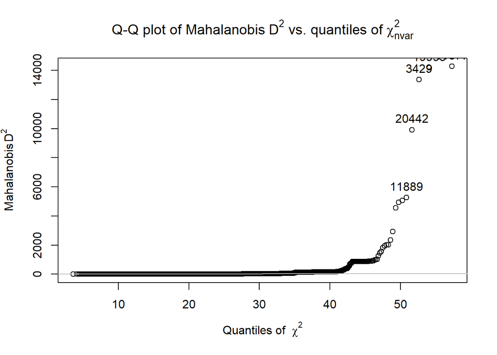

[output not shown]

[output cut: 6719 more lines]

[output not shown]

### 3.2 Normalização dos dados

Retirar Malahanobis?

```r
alpha <- .0001

cutoff <- (qchisq(p = 1 - alpha,
                  df = ncol(base_dummy_std)))

# Mahalanobis

md <- mahalanobis(base_dummy_std,
                  center = colMeans(base_dummy_std),
                  cov = cov(base_dummy_std))

names_outliers_MH <- which(md > cutoff)

base_dummy_clean_mh <- base_dummy[-names_outliers_MH, ]
base_clean_mh <- base[-names_outliers_MH, ]


# Minimum Covariance Determinant}
# https://doi.org/10.1002/wics.1421

if(!require(robustbase)){
  install.packages("robustbase")
  library(robustbase)
}
output75 <- robustbase::covMcd(base_dummy_std,
                               alpha = .75)
mhmcd75 <- mahalanobis(base_dummy_std, output75$center, output75$cov)

names_outlier_mcd <- which(mhmcd75 > cutoff)

base_dummy_clean_mcd <- base_dummy[-names_outlier_mcd, ]
base_clean_mcd <- base[-names_outlier_mcd, ]
```

```r
psych::describe(base_dummy_clean_mcd)
```

```
##                                    vars     n      mean         sd   median
## SEXO.F                                1 26493      0.50       0.50      1.0
## ESCOLARIDADE.DOUTORADO                2 26493      0.00       0.00      0.0
## ESCOLARIDADE.ENSINO.FUNDAMENTAL       3 26493      0.12       0.32      0.0
## ESCOLARIDADE.ENSINO.MEDIO             4 26493      0.36       0.48      0.0
## ESCOLARIDADE.MESTRADO                 5 26493      0.00       0.00      0.0
## ESCOLARIDADE.POS.GRADUADO             6 26493      0.03       0.16      0.0
## ESCOLARIDADE.SUPERIOR.COMPLETO        7 26493      0.43       0.49      0.0
## ESCOLARIDADE.SUPERIOR.EM.ANDAMENTO    8 26493      0.07       0.25      0.0
## RENDA                                 9 26493   6665.59    4587.69   5502.2
## TARIFA_062016                        10 26493    670.70    1036.98    405.5
## MARGEM_062016                        11 26493   4642.45   10022.45   1230.8
## RELACIONAMENTO.DIGITAL               12 26493      0.31       0.46      0.0
## REGIAO.Nordeste                      13 26493      0.24       0.43      0.0
## REGIAO.Norte                         14 26493      0.08       0.27      0.0
## REGIAO.Sudeste                       15 26493      0.42       0.49      0.0
## REGIAO.Sul                           16 26493      0.16       0.37      0.0
## IDADE                                17 26493     51.60      14.87     51.0
## TEMPO_REL                            18 26493     17.77       7.80     17.0
## VOLUME_062016                        19 26493 562644.09 1261433.38 166512.6
## VOLUME_062019                        20 26493 725169.31 1731278.59 208486.3
##                                      trimmed       mad        min      max
## SEXO.F                                  0.50      0.00       0.00        1
## ESCOLARIDADE.DOUTORADO                  0.00      0.00       0.00        0
## ESCOLARIDADE.ENSINO.FUNDAMENTAL         0.02      0.00       0.00        1
## ESCOLARIDADE.ENSINO.MEDIO               0.33      0.00       0.00        1
## ESCOLARIDADE.MESTRADO                   0.00      0.00       0.00        0
## ESCOLARIDADE.POS.GRADUADO               0.00      0.00       0.00        1
## ESCOLARIDADE.SUPERIOR.COMPLETO          0.41      0.00       0.00        1
## ESCOLARIDADE.SUPERIOR.EM.ANDAMENTO      0.00      0.00       0.00        1
## RENDA                                5980.54   2591.01      70.56    59906
## TARIFA_062016                         492.02    409.11   -4698.72    23477
## MARGEM_062016                        2495.16   1543.88 -111516.32   171583
## RELACIONAMENTO.DIGITAL                  0.26      0.00       0.00        1
## REGIAO.Nordeste                         0.17      0.00       0.00        1
## REGIAO.Norte                            0.00      0.00       0.00        1
## REGIAO.Sudeste                          0.40      0.00       0.00        1
## REGIAO.Sul                              0.08      0.00       0.00        1
## IDADE                                  50.93     17.79      20.00       90
## TEMPO_REL                              17.08      7.41       2.00       70
```

[output cut: 8 more lines]

```
## ESCOLARIDADE.POS.GRADUADO                 1  6.01    34.16     0.00
## ESCOLARIDADE.SUPERIOR.COMPLETO            1  0.29    -1.92     0.00
## ESCOLARIDADE.SUPERIOR.EM.ANDAMENTO        1  3.50    10.26     0.00
## RENDA                                 59836  3.16    18.48    28.19
## TARIFA_062016                         28175  7.28    91.42     6.37
## MARGEM_062016                        283099  5.01    44.48    61.58
## RELACIONAMENTO.DIGITAL                    1  0.83    -1.31     0.00
## REGIAO.Nordeste                           1  1.23    -0.49     0.00
## REGIAO.Norte                              1  3.12     7.74     0.00
## REGIAO.Sudeste                            1  0.32    -1.90     0.00
## REGIAO.Sul                                1  1.84     1.37     0.00
## IDADE                                    70  0.34    -0.71     0.09
## TEMPO_REL                                68  0.87     1.09     0.05
## VOLUME_062016                      26022727  7.16    79.26  7749.95
## VOLUME_062019                      43365592  8.82   126.38 10636.56
```

## 4. Modelagem

### 4.1 Separacao de base de treino e teste

Os modelos de ML devem ser treinados com uma base e, ao final de todo o processo testados com outra, para verificar sua capacidade de prever a partir de números desconhecidos. Portanto, nesta etapa e feita da separacao das bases, que neste caso utilizara 70% dos dados para treino, e 30% para o teste final. A partir da base de treino, é ainda feita a separação de uma base para validação dos modelos, que também deve ser feita com dados distintos dos utilizados no treino.

```r
trans_std <- preProcess(base_dummy_clean_mcd,
                        method = c("center", "scale"))
base_dummy_clean_mcd_std <- predict(trans_std, base_dummy_clean_mcd)

set.seed(101)
sample = sample.split(base_dummy_clean_mcd_std$RELACIONAMENTO.DIGITAL,
                      SplitRatio =0.7)
pretrain = subset(base_dummy_clean_mcd_std, sample == TRUE)
test  = subset(base_dummy_clean_mcd_std, sample == FALSE)
```

### 4.2 Modelo de Regressão Multivariada

#### Tunning do Modelo

```r
# Set up repeated k-fold cross-validation

train.control <- trainControl(method = "cv", number = 10)

cl <- makeCluster(8) # use 8 workers
registerDoParallel(cl) # register the parallel backend

#https://www.rdocumentation.org/packages/MASS/versions/7.3-53/topics/stepAIC

set.seed(42)
step.model.AIC <- train(VOLUME_062019 ~ (.)*RELACIONAMENTO.DIGITAL,
                        data = pretrain,
                        method = "lmStepAIC",
                        trControl = train.control
                        )
```

```
## Start:  AIC=-19024
## .outcome ~ SEXO.F + ESCOLARIDADE.DOUTORADO + ESCOLARIDADE.ENSINO.FUNDAMENTAL +
##     ESCOLARIDADE.ENSINO.MEDIO + ESCOLARIDADE.MESTRADO + ESCOLARIDADE.POS.GRADUADO +
##     ESCOLARIDADE.SUPERIOR.COMPLETO + ESCOLARIDADE.SUPERIOR.EM.ANDAMENTO +
##     RENDA + TARIFA_062016 + MARGEM_062016 + RELACIONAMENTO.DIGITAL +
##     REGIAO.Nordeste + REGIAO.Norte + REGIAO.Sudeste + REGIAO.Sul +
##     IDADE + TEMPO_REL + VOLUME_062016 + `SEXO.F:RELACIONAMENTO.DIGITAL` +
##     `ESCOLARIDADE.DOUTORADO:RELACIONAMENTO.DIGITAL` + `ESCOLARIDADE.ENSINO.FUNDAMENTAL:RELACIONAMENTO.DIGITAL` +
##     `ESCOLARIDADE.ENSINO.MEDIO:RELACIONAMENTO.DIGITAL` + `ESCOLARIDADE.MESTRADO:RELACIONAMENTO.DIGITAL` +
##     `ESCOLARIDADE.POS.GRADUADO:RELACIONAMENTO.DIGITAL` + `ESCOLARIDADE.SUPERIOR.COMPLETO:RELACIONAMENTO.DIGITAL` +
##     `ESCOLARIDADE.SUPERIOR.EM.ANDAMENTO:RELACIONAMENTO.DIGITAL` +
##     `RENDA:RELACIONAMENTO.DIGITAL` + `TARIFA_062016:RELACIONAMENTO.DIGITAL` +
##     `MARGEM_062016:RELACIONAMENTO.DIGITAL` + `RELACIONAMENTO.DIGITAL:REGIAO.Nordeste` +
##     `RELACIONAMENTO.DIGITAL:REGIAO.Norte` + `RELACIONAMENTO.DIGITAL:REGIAO.Sudeste` +
##     `RELACIONAMENTO.DIGITAL:REGIAO.Sul` + `RELACIONAMENTO.DIGITAL:IDADE` +
##     `RELACIONAMENTO.DIGITAL:TEMPO_REL` + `RELACIONAMENTO.DIGITAL:VOLUME_062016`
##
##
## Step:  AIC=-19024
## .outcome ~ SEXO.F + ESCOLARIDADE.DOUTORADO + ESCOLARIDADE.ENSINO.FUNDAMENTAL +
##     ESCOLARIDADE.ENSINO.MEDIO + ESCOLARIDADE.MESTRADO + ESCOLARIDADE.POS.GRADUADO +
##     ESCOLARIDADE.SUPERIOR.COMPLETO + ESCOLARIDADE.SUPERIOR.EM.ANDAMENTO +
##     RENDA + TARIFA_062016 + MARGEM_062016 + RELACIONAMENTO.DIGITAL +
##     REGIAO.Nordeste + REGIAO.Norte + REGIAO.Sudeste + REGIAO.Sul +
##     IDADE + TEMPO_REL + VOLUME_062016 + `SEXO.F:RELACIONAMENTO.DIGITAL` +
##     `ESCOLARIDADE.DOUTORADO:RELACIONAMENTO.DIGITAL` + `ESCOLARIDADE.ENSINO.FUNDAMENTAL:RELACIONAMENTO.DIGITAL` +
##     `ESCOLARIDADE.ENSINO.MEDIO:RELACIONAMENTO.DIGITAL` + `ESCOLARIDADE.MESTRADO:RELACIONAMENTO.DIGITAL` +
##     `ESCOLARIDADE.POS.GRADUADO:RELACIONAMENTO.DIGITAL` + `ESCOLARIDADE.SUPERIOR.COMPLETO:RELACIONAMENTO.DIGITAL` +
##     `RENDA:RELACIONAMENTO.DIGITAL` + `TARIFA_062016:RELACIONAMENTO.DIGITAL` +
##     `MARGEM_062016:RELACIONAMENTO.DIGITAL` + `RELACIONAMENTO.DIGITAL:REGIAO.Nordeste` +
##     `RELACIONAMENTO.DIGITAL:REGIAO.Norte` + `RELACIONAMENTO.DIGITAL:REGIAO.Sudeste` +
##     `RELACIONAMENTO.DIGITAL:REGIAO.Sul` + `RELACIONAMENTO.DIGITAL:IDADE` +
##     `RELACIONAMENTO.DIGITAL:TEMPO_REL` + `RELACIONAMENTO.DIGITAL:VOLUME_062016`
##
##
## Step:  AIC=-19024
## .outcome ~ SEXO.F + ESCOLARIDADE.DOUTORADO + ESCOLARIDADE.ENSINO.FUNDAMENTAL +
##     ESCOLARIDADE.ENSINO.MEDIO + ESCOLARIDADE.MESTRADO + ESCOLARIDADE.POS.GRADUADO +
##     ESCOLARIDADE.SUPERIOR.COMPLETO + ESCOLARIDADE.SUPERIOR.EM.ANDAMENTO +
##     RENDA + TARIFA_062016 + MARGEM_062016 + RELACIONAMENTO.DIGITAL +
```

[output cut: 1188 more lines]

```
##                                                               AIC
## <none>                                                     -19052
## - `RELACIONAMENTO.DIGITAL:REGIAO.Norte`                    -19051
## - `RELACIONAMENTO.DIGITAL:IDADE`                           -19051
## - TEMPO_REL                                                -19050
## - `RELACIONAMENTO.DIGITAL:REGIAO.Sul`                      -19049
## - `ESCOLARIDADE.ENSINO.FUNDAMENTAL:RELACIONAMENTO.DIGITAL` -19049
## - `RELACIONAMENTO.DIGITAL:TEMPO_REL`                       -19043
## - TARIFA_062016                                            -19042
## - `MARGEM_062016:RELACIONAMENTO.DIGITAL`                   -19039
## - `RENDA:RELACIONAMENTO.DIGITAL`                           -19038
## - `TARIFA_062016:RELACIONAMENTO.DIGITAL`                   -18950
## - RENDA                                                    -18877
## - MARGEM_062016                                            -18753
## - VOLUME_062016                                             -9360
```

```r
stopCluster(cl)
registerDoSEQ()

step.model.AIC$results
```

```
##   parameter   RMSE Rsquared   MAE  RMSESD RsquaredSD   MAESD
## 1      none 0.5966   0.6195 0.245 0.09736    0.06599 0.01395
```

```r
coef(step.model.AIC$finalModel)
```

```
##                                              (Intercept)
##                                                 0.003813
##                                                    RENDA
##                                                 0.062300
##                                            TARIFA_062016
##                                                 0.019146
##                                            MARGEM_062016
##                                                 0.091536
##                                                TEMPO_REL
##                                                 0.008929
##                                            VOLUME_062016
##                                                 0.688775
## `ESCOLARIDADE.ENSINO.FUNDAMENTAL:RELACIONAMENTO.DIGITAL`
##                                                -0.009286
##                           `RENDA:RELACIONAMENTO.DIGITAL`
##                                                 0.017123
##                   `TARIFA_062016:RELACIONAMENTO.DIGITAL`
##                                                 0.049215
##                   `MARGEM_062016:RELACIONAMENTO.DIGITAL`
##                                                -0.018476
##                    `RELACIONAMENTO.DIGITAL:REGIAO.Norte`
##                                                -0.006394
##                      `RELACIONAMENTO.DIGITAL:REGIAO.Sul`
##                                                -0.008821
##                           `RELACIONAMENTO.DIGITAL:IDADE`
##                                                 0.008839
##                       `RELACIONAMENTO.DIGITAL:TEMPO_REL`
##                                                -0.017406
```

#### Modelo definitivo

```r
best_regr <- lm(VOLUME_062019 ~ ESCOLARIDADE.ENSINO.FUNDAMENTAL +
                  ESCOLARIDADE.ENSINO.MEDIO +
                  (RENDA + TARIFA_062016 + MARGEM_062016 +
                     TEMPO_REL + VOLUME_062016)*RELACIONAMENTO.DIGITAL,
                data = pretrain)

summary(best_regr)
```

```
##
## Call:
## lm(formula = VOLUME_062019 ~ ESCOLARIDADE.ENSINO.FUNDAMENTAL +
##     ESCOLARIDADE.ENSINO.MEDIO + (RENDA + TARIFA_062016 + MARGEM_062016 +
##     TEMPO_REL + VOLUME_062016) * RELACIONAMENTO.DIGITAL, data = pretrain)
##
## Residuals:
##    Min     1Q Median     3Q    Max
## -8.600 -0.132 -0.037  0.054 17.171
##
## Coefficients:
##                                       Estimate Std. Error t value
## (Intercept)                           0.000585   0.004406    0.13
## ESCOLARIDADE.ENSINO.FUNDAMENTAL      -0.009670   0.004705   -2.06
## ESCOLARIDADE.ENSINO.MEDIO            -0.000933   0.004590   -0.20
## RENDA                                 0.061210   0.004701   13.02
## TARIFA_062016                         0.018924   0.005534    3.42
## MARGEM_062016                         0.091129   0.005268   17.30
## TEMPO_REL                             0.010415   0.004520    2.30
## VOLUME_062016                         0.688002   0.006114  112.53
## RELACIONAMENTO.DIGITAL               -0.001055   0.004463   -0.24
## RENDA:RELACIONAMENTO.DIGITAL          0.016276   0.004435    3.67
## TARIFA_062016:RELACIONAMENTO.DIGITAL  0.048335   0.005436    8.89
## MARGEM_062016:RELACIONAMENTO.DIGITAL -0.019993   0.005230   -3.82
## TEMPO_REL:RELACIONAMENTO.DIGITAL     -0.013560   0.004614   -2.94
## VOLUME_062016:RELACIONAMENTO.DIGITAL  0.003902   0.005992    0.65
##                                                  Pr(>|t|)
## (Intercept)                                       0.89441
## ESCOLARIDADE.ENSINO.FUNDAMENTAL                   0.03988 *
## ESCOLARIDADE.ENSINO.MEDIO                         0.83890
## RENDA                                < 0.0000000000000002 ***
## TARIFA_062016                                     0.00063 ***
## MARGEM_062016                        < 0.0000000000000002 ***
## TEMPO_REL                                         0.02124 *
## VOLUME_062016                        < 0.0000000000000002 ***
## RELACIONAMENTO.DIGITAL                            0.81310
## RENDA:RELACIONAMENTO.DIGITAL                      0.00024 ***
## TARIFA_062016:RELACIONAMENTO.DIGITAL < 0.0000000000000002 ***
## MARGEM_062016:RELACIONAMENTO.DIGITAL              0.00013 ***
## TEMPO_REL:RELACIONAMENTO.DIGITAL                  0.00330 **
## VOLUME_062016:RELACIONAMENTO.DIGITAL              0.51493
## ---
## Signif. codes:  0 '***' 0.001 '**' 0.01 '*' 0.05 '.' 0.1 ' ' 1
##
## Residual standard error: 0.598 on 18531 degrees of freedom
## Multiple R-squared:  0.619,  Adjusted R-squared:  0.619
## F-statistic: 2.32e+03 on 13 and 18531 DF,  p-value: <0.0000000000000002
```

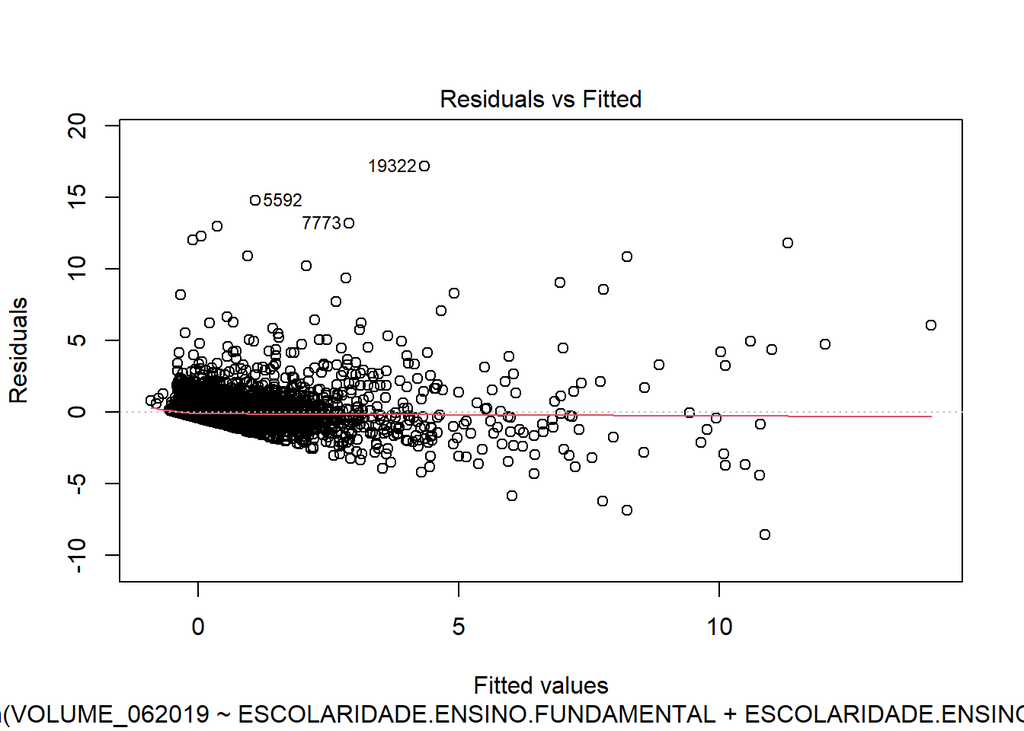

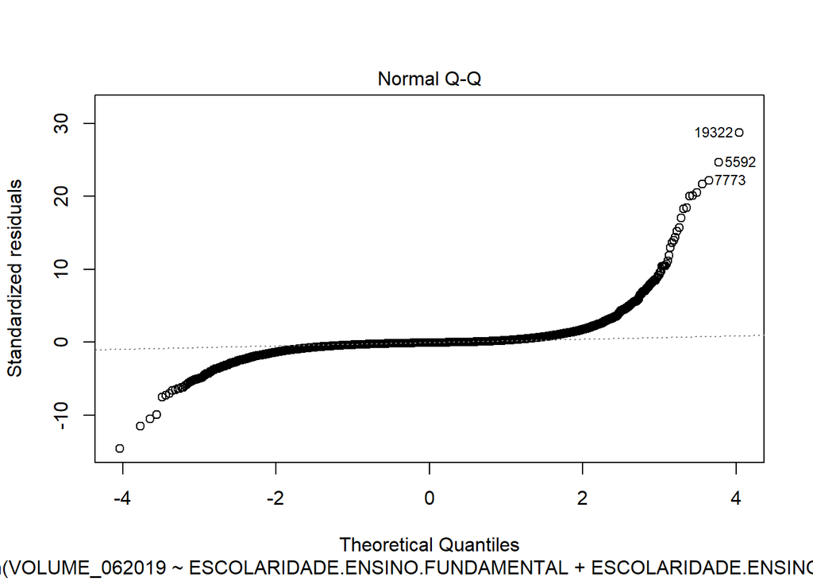

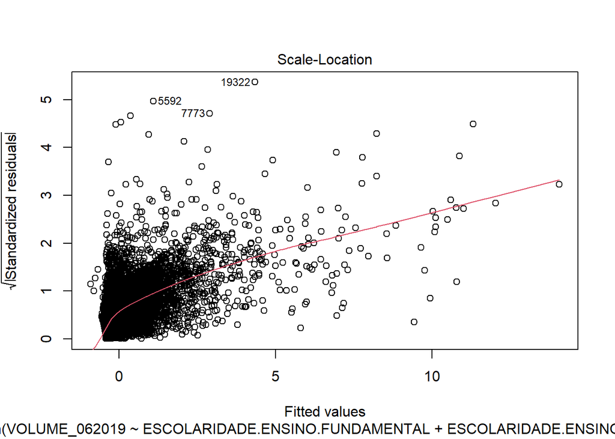

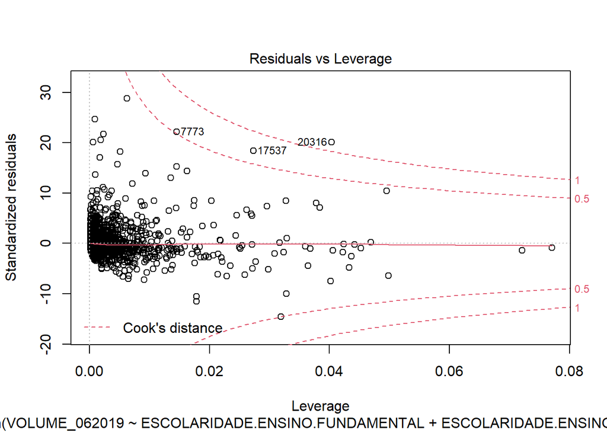

```r
plot(best_regr)
```

```r
outs <- car::outlierTest(best_regr)
outs$rstudent
```

```
## 19322  5592  7773 11112  8250 20316 12424 17537  8560 19023
## 29.46 25.14 22.49 22.02 20.79 20.37 20.30 18.59 18.43 17.17
```

```r
VOL_pred <- predict(best_regr, newdata=test, type="response")
RMSE <- sqrt(mean((test$VOLUME_062019-VOL_pred)^2))
paste("RMSE na amostra de teste = ", RMSE)
```

```
## [1] "RMSE na amostra de teste =  0.625545406274704"
```

### 4.3 Árvores de decisão

#### Tunning do Modelo

```r
train.control <- trainControl(method = "cv", number = 10)

cl <- makeCluster(8) # use 8 workers
registerDoParallel(cl) # register the parallel backend
```

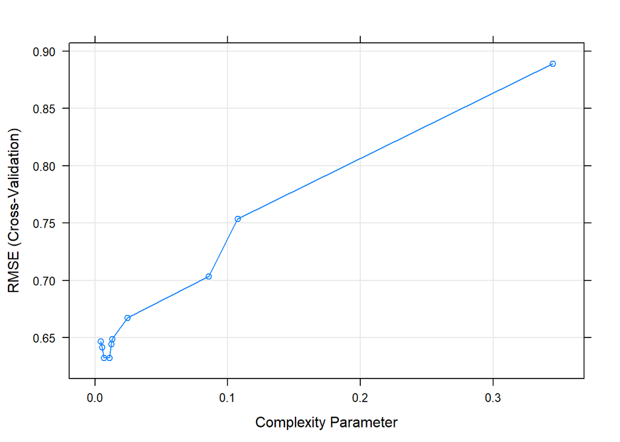

```r
set.seed(42)
Rpart <- train(VOLUME_062019 ~ ., data = pretrain,
             method="rpart",
             trControl=train.control,
             tuneLength=10)
plot(Rpart)
```

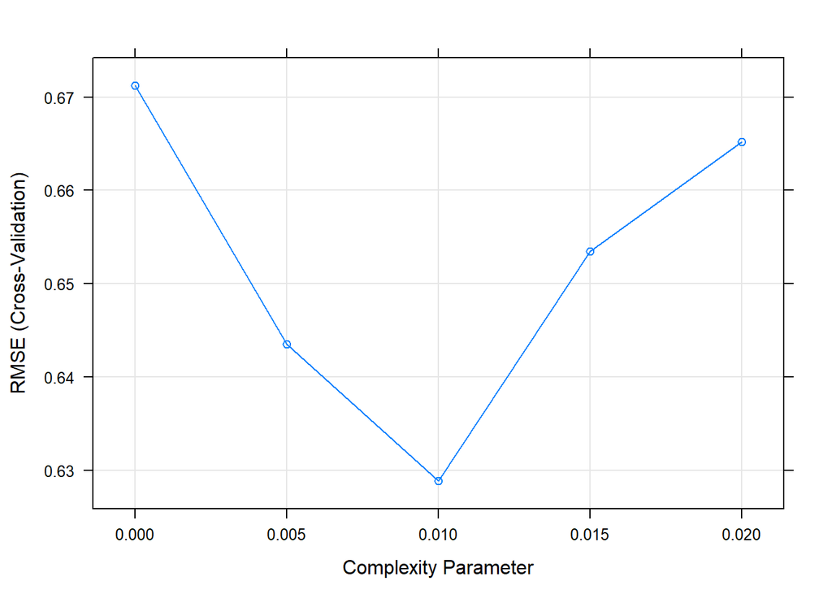

```r
set.seed(42)
Rpart <- train(VOLUME_062019 ~ ., data = pretrain,
             method="rpart",
             trControl=train.control,
             tuneGrid = expand.grid(cp=seq(0,0.02,0.005)))
plot(Rpart)
```

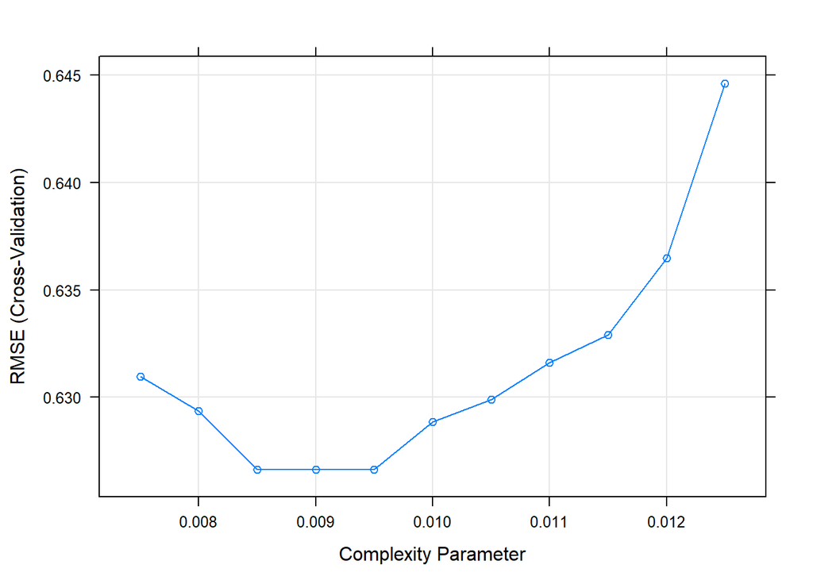

```r
set.seed(42)
Rpart <- train(VOLUME_062019 ~ ., data = pretrain,
             method="rpart",
             trControl=train.control,
             tuneGrid = expand.grid(cp=seq(0.0075,0.0125,0.0005)))
plot(Rpart)
```

#### Modelo definitivo

```r
set.seed(42)
Rpart <- rpart(VOLUME_062019 ~ .,
               data = pretrain,
               control=list(cp = 0.011)
              )

varImp(Rpart)
```

```
##                                     Overall
## ESCOLARIDADE.ENSINO.MEDIO          0.031776
## IDADE                              0.037397
## MARGEM_062016                      0.556756
## REGIAO.Sudeste                     0.004086
## RENDA                              0.333176
## TARIFA_062016                      0.529872
## TEMPO_REL                          0.058018
## VOLUME_062016                      1.474043
## SEXO.F                             0.000000
## ESCOLARIDADE.DOUTORADO             0.000000
## ESCOLARIDADE.ENSINO.FUNDAMENTAL    0.000000
## ESCOLARIDADE.MESTRADO              0.000000
## ESCOLARIDADE.POS.GRADUADO          0.000000
## ESCOLARIDADE.SUPERIOR.COMPLETO     0.000000
## ESCOLARIDADE.SUPERIOR.EM.ANDAMENTO 0.000000
## RELACIONAMENTO.DIGITAL             0.000000
## REGIAO.Nordeste                    0.000000
## REGIAO.Norte                       0.000000
## REGIAO.Sul                         0.000000
```

```r
test$Rpart <- predict(Rpart, newdata=test)
RMSERpart <- sqrt(mean((test$VOLUME_062019-test$Rpart)^2))
paste("RMSE na amostra de teste = ", RMSERpart)
```

```
## [1] "RMSE na amostra de teste =  0.680790832243166"
```

```r
stopCluster(cl)
registerDoSEQ()
```

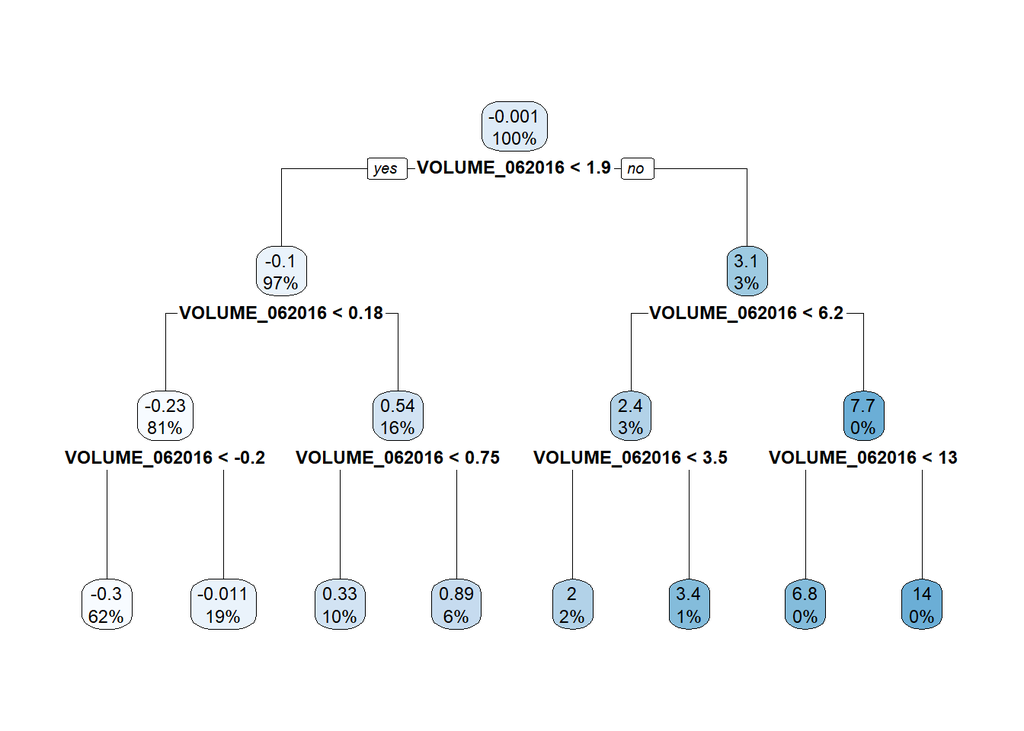

```r
if(!require(rpart.plot)){
  install.packages("rpart.plot", dependencies = TRUE)
  library(rpart.plot)
}

rpart.plot(Rpart)
```

### 4.4 Bagged Trees

#### Tunning do Modelo

```r
sample = sample.split(pretrain$RELACIONAMENTO.DIGITAL,
                      SplitRatio =0.7)
pretrain_tr = subset(pretrain, sample == TRUE)
pretrain_vl = subset(pretrain, sample == FALSE)

cl <- makeCluster(8) # use 8 workers
registerDoParallel(cl) # register the parallel backend

predictions <- foreach(
  icount(300),
  .packages = "rpart",
  .combine = cbind
  ) %dopar% {
    # bootstrap copy of training data
    index <- sample(nrow(pretrain_tr), replace = TRUE)
    base_train_boot <- pretrain_tr[index, ]

    # fit tree to bootstrap copy
    bagged_tree <- rpart(VOLUME_062019 ~ .,
                         control = rpart.control(cp = 0.011),
                         data = base_train_boot
                         )

    predict(bagged_tree, newdata = pretrain_vl)
    }

stopCluster(cl)
registerDoSEQ()
```

```r
pred_plot <- predictions %>%
  as.data.frame() %>%
  mutate(
    observation = 1:n(),
    actual = pretrain_vl$VOLUME_062019) %>%
  tidyr::gather(tree, predicted, -c(observation, actual)) %>%
  group_by(observation) %>%
  mutate(tree = stringr::str_extract(tree, '\\d+') %>% as.numeric()) %>%
  ungroup() %>%
  arrange(observation, tree) %>%
  group_by(observation) %>%
  mutate(avg_prediction = cummean(predicted)) %>%
  group_by(tree) %>%
  summarize(RMSE = RMSE(avg_prediction, actual))
```

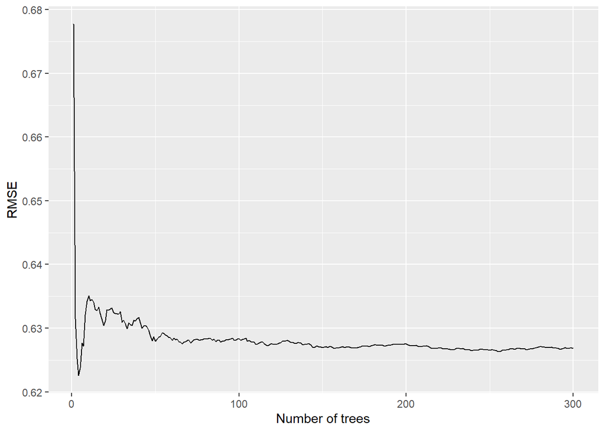

```r
pred_plot %>%
  ggplot(aes(tree, RMSE)) +
  geom_line() +
  xlab('Number of trees')
```

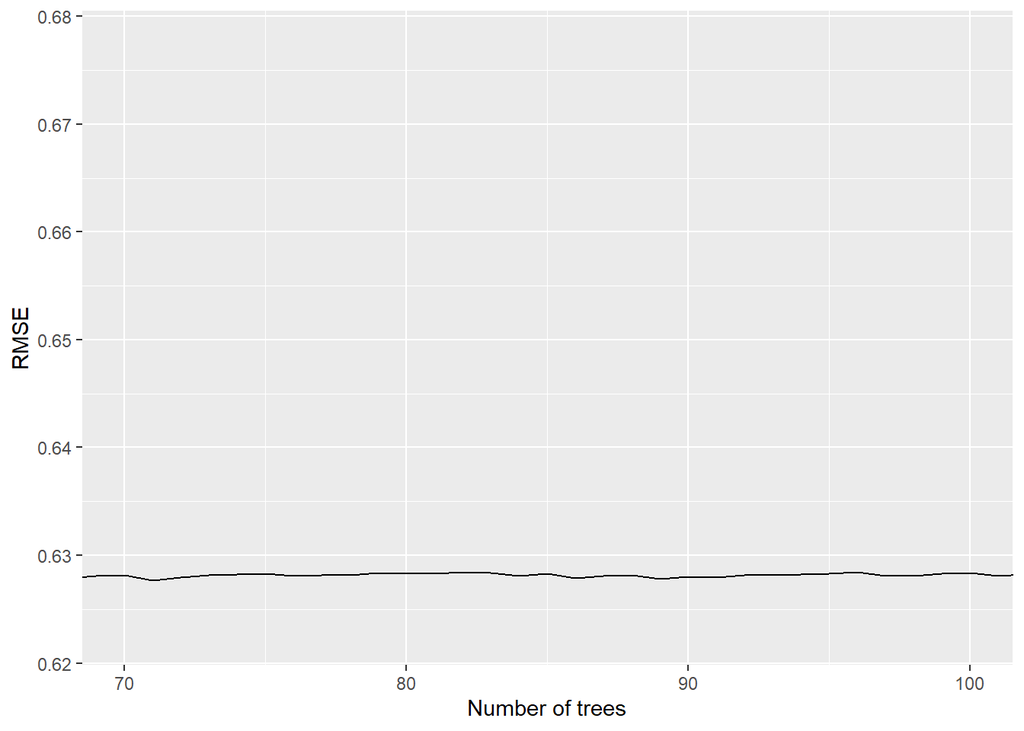

```r
pred_plot %>%
  ggplot(aes(tree, RMSE)) +
  geom_line() +
  xlab('Number of trees') +
  coord_cartesian(xlim = c(70, 100))
```